# 8-6-1 checks

Abhishek Singh

02-March- 2023

Data for 2001 Q4 to 2022 Q4 have been created and saved as 2023-03-02_8-6-1.csv in the 8-6-1 Output folder.

### Check configurations

Please check that the information below is as you expect. In particular, pay attention to the time since data were saved, to check that previously downloaded data have not accidentally been used.

These settings can all be adjusted in `config.R`

Files used to create the new data were downloaded and saved in 8-6-1/Example_Input.

**Proportion of youth (aged 15–24 years) not in education, employment or training**

This file was saved at 2023-02-21 11:00:07: It has been 9.28 days since the file was saved in Example_Input

The tab used is called Source 1.

### Check data

The charts below show the new data (just created) plotted on top of the old data, which has been downloaded from the live site. If there are unexpected discrepancies in the lines please investigate the reasons for these discrepancies.

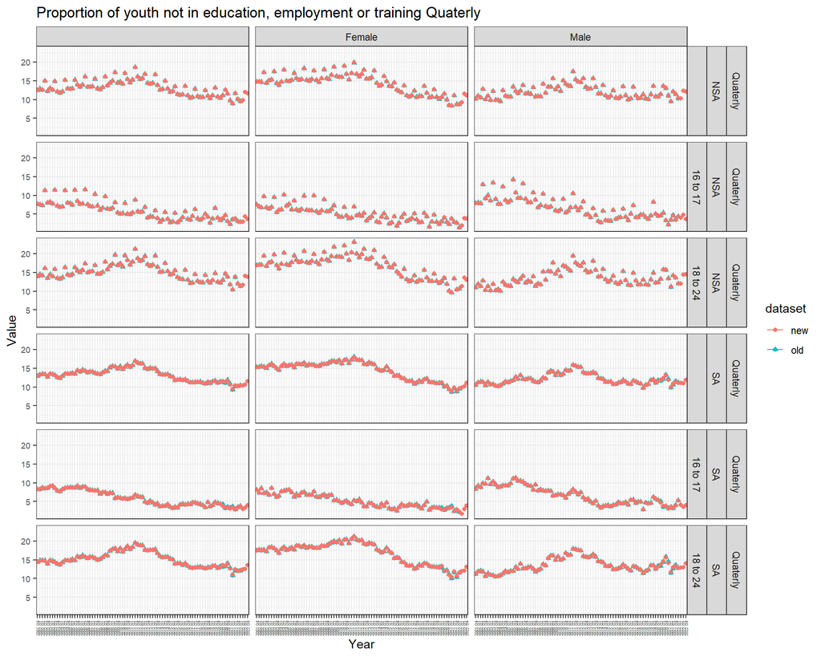

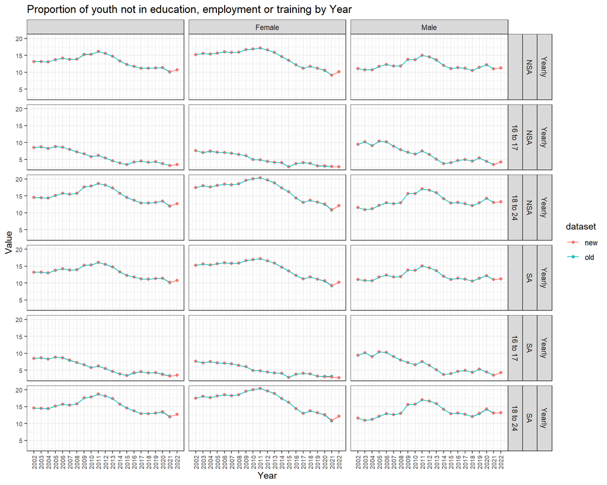

Warning: This is copied from `update_8-6-1.R` and will not dynamically update if that code is changed.